# Lab 2

### Graphically:

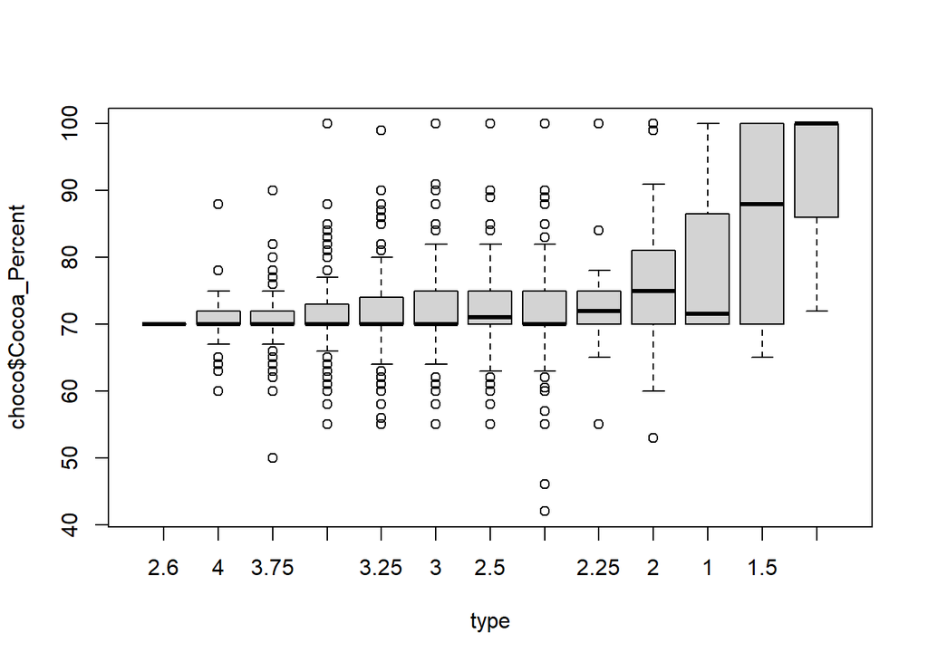

   ```r
   type <- reorder(choco$Rating, choco$Cocoa_Percent, mean, na.rm=TRUE)
   boxplot(choco$Cocoa_Percent ~ type)
   ```

4. How do different bean origins compare in terms of the flavor of chocolates? Are beans from some places better than the other? Create both numerical and graphical summaries, and explain.

   Answer:

   ```r
   aggregate(choco$Rating ~ choco$Bean_Origin, FUN = mean)
   ```

   ```
   ##        choco$Bean_Origin choco$Rating
   ## 1              Australia     3.250000
   ## 2                 Belize     3.227612
   ## 3                  blend     3.000000
   ## 4                  Blend     3.034768
   ## 5                Bolivia     3.180556
   ## 6                 Bolvia     3.250000
   ## 7                 Brazil     3.253333
   ## 8                  Burma     3.000000
   ## 9               Cameroon     3.083333
   ## 10              Colombia     3.204545
   ## 11                 Congo     3.318182
   ## 12            Costa Rica     3.151163
   ## 13                  Cuba     3.291667
   ## 14    Dominican Republic     3.201942
   ```

   [output cut: 49 more lines]

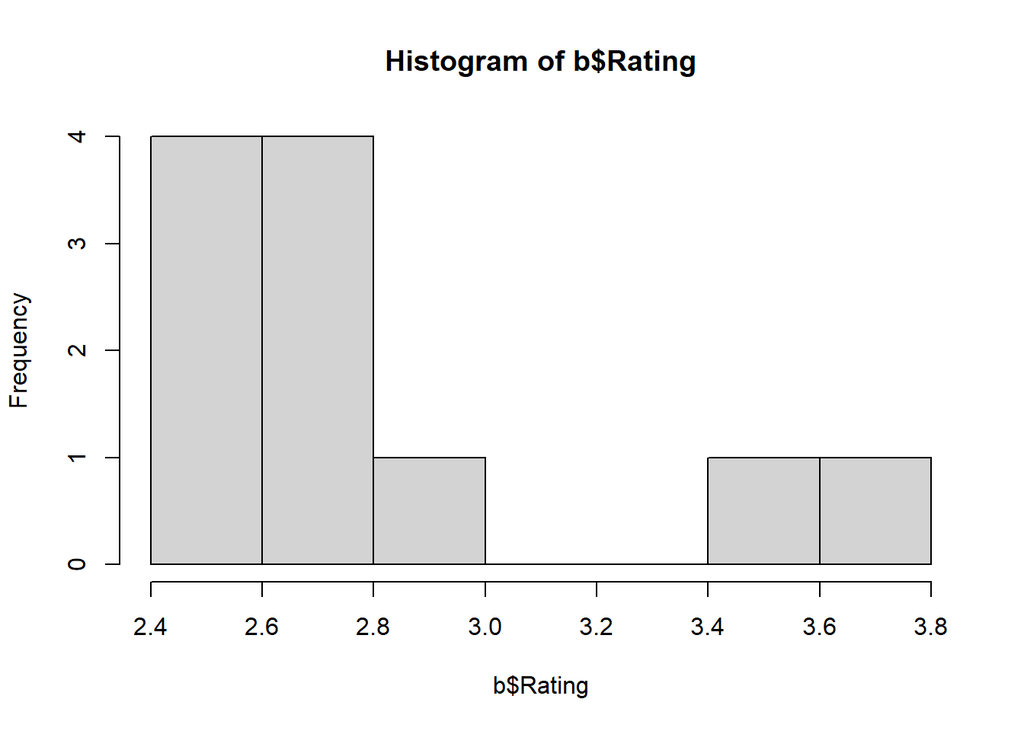

   ```r
   b <- choco[choco$Bean_Origin == 'Uganda',]
   hist(b$Rating)
   ```

5. Brainstorm two analyses you would like to perform (with your teammates). Describe in plain language what comparisons are you making. Create suitable numerical and graphical summaries for your analyses. Describe the results.
   1. First analysis - Which location produces the highest rating?

   ```r
   aggregate(choco$Rating ~ choco$Location, FUN = mean)
   ```

   ```
   ##           choco$Location choco$Rating
   ## 1              Amsterdam     3.312500
   ## 2              Argentina     3.305556
   ## 3              Australia     3.358491
   ## 4                Austria     3.258333
   ## 5                Belgium     3.105932
   ## 6                Bolivia     3.250000
   ## 7                 Brazil     3.281250
   ## 8                 Canada     3.301242
   ## 9                  Chile     3.750000
   ## 10              Colombia     3.160000
   ## 11            Costa Rica     3.138889
   ## 12        Czech Republic     3.000000
   ## 13               Denmark     3.338710
   ## 14    Dominican Republic     3.122727
   ```

   [output cut: 53 more lines]

   The Chile Locations appear to rate chocolate the highest

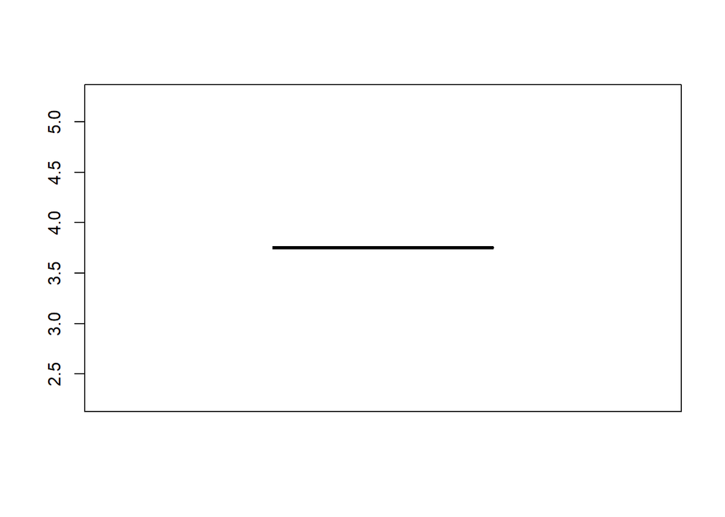

   ```r
   f <- choco[choco$Location == 'Chile',]
   boxplot(f$Rating)
   ```

   1. As chocolate gotten better each year?

   ```r
   f <- aggregate(choco$Rating ~ choco$Date, FUN = mean, rm_na = True)
   f
   ```

   ```
   ##    choco$Date choco$Rating
   ## 1        2006     3.004032
   ## 2        2007     3.102740
   ## 3        2008     3.000000
   ## 4        2009     3.073171
   ## 5        2010     3.152273
   ## 6        2011     3.257669
   ## 7        2012     3.180412
   ## 8        2013     3.197011
   ## 9        2014     3.189271
   ## 10       2015     3.244718
   ## 11       2016     3.226027
   ## 12       2017     3.361905
   ## 13       2018     3.192325
   ## 14       2019     3.133333
   ## 15       2020     3.159091
   ```

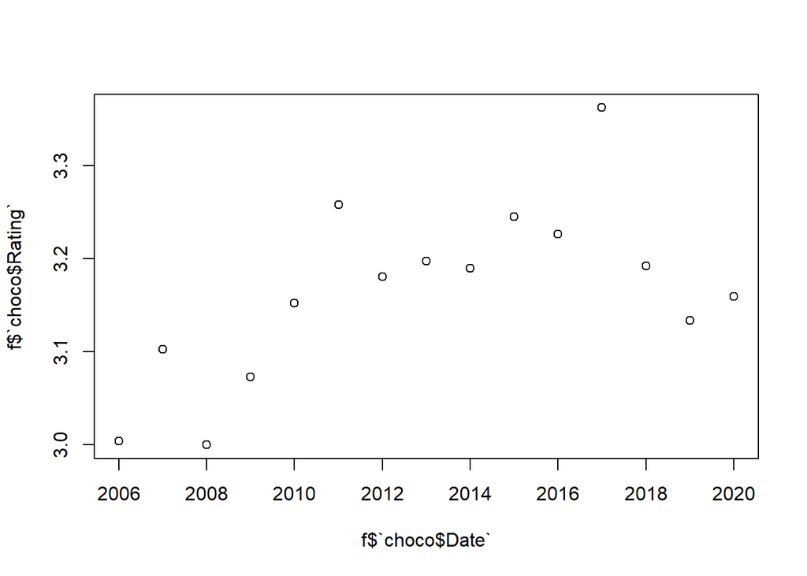

   ```r
   plot(f$`choco$Date`, f$`choco$Rating`)
   ```

   The average rating of chocolate has seemed to subtly improved over time. Older dates (2006- 2010) had lower ratings on average than new dates (2018+)